# A Psychometric Investigation of Creativity Ratings in Football

Utilizing Judge Response Theory to Model Rater Effects

Maximilian Klemp-Weins

Institute of Exercise Training and Sport Informatics · German Sport University Cologne

17 November 2026

# 1 · Creativity as a construct

## Why creativity, and what it is

- Creative thinking is listed among the core competences for work and education (OECD, 2024; World Economic Forum, 2025).
- In sport, creative actions decide tight games, and creativity is a declared training goal (de Sa Fardilha & Allen, 2020; Santos et al., 2016).

**The standard definition** (Runco & Jaeger, 2012; Stein, 1953)

“Creativity requires both **originality** and **effectiveness**.” Original things must also work: useful, fitting, appropriate in context.

- But “creative” is used loosely: for people, processes, environments and products alike. **Which of these do we measure, and how?**

## A credibility problem, and a reset in 2019

**For decades, creativity assessment suffered from**

- inconsistent terminology (“creativity” meaning different things in different studies),
- no shared taxonomy of what is being measured,
- weak psychometric reporting of the instruments.

Result: the construct lost credibility outside the field.

[figure not shown]

“That notwithstanding, enduring **conceptual and methodological issues** and the **lack of established assessment standards** still challenge the validity of creativity studies, limit meta-analytical work, and make the creativity literature at times elusive to the novice eye.” (Barbot & Reiter-Palmon, 2019, p. 131)

## Which facet? Taxonomies of creativity

**Rhodes’s four Ps** (Rhodes, 1961)

- **Person**: traits, abilities, personality
- **Process**: thinking, motivation, learning
- **Press**: the environment that presses on person and process
- **Product**: the idea or artefact that is judged

The classic frame for sorting creativity measures.

**Batey’s heuristic framework** (Batey, 2012): the four Ps as one axis, joined with level and measurement approach

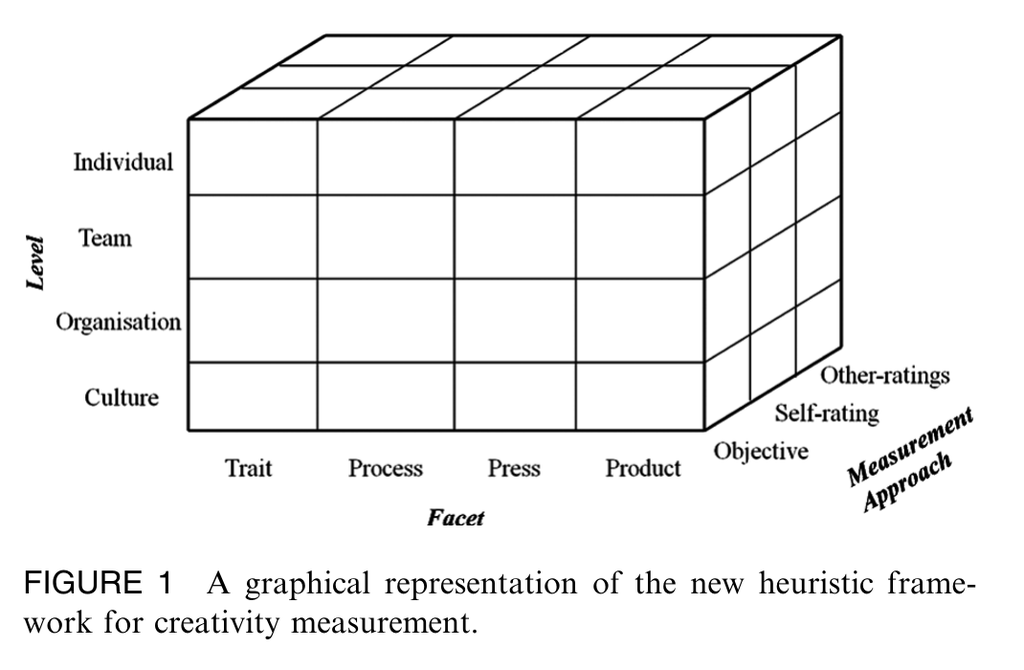

**This study sits in one cell:** individual · **product** · **other-ratings**. Single actions of a player, rated by independent observers.

## How creativity is assessed

**Divergent thinking tasks**  
“Name unusual uses of a brick.” Fluency, flexibility, originality. Also convergent-thinking and insight tasks  
Facet: *Process*

**Self- and other-reports**  
Questionnaires, achievement and activity inventories, personality  
Facet: *Person*

**Consensual Assessment Technique (CAT)**  
Experts rate products independently. Also non-CAT ratings by teachers or coaches  
Facet: *Product*

## How creativity is assessed

**Divergent thinking tasks**

**Self- and other-reports**

**Consensual Assessment Technique (CAT)**

Snyder et al. (2019) coded every creativity measure in 446 studies (1984–2013):

**43%**  
divergent / convergent thinking

**45%**  
self-report

**34%**  
product ratings, CAT and non-CAT

Shares of studies; they exceed 100% because many studies use several measures; other measures 16%.

- **CAT** (Amabile, 1982; Hennessey et al., 2011; Kaufman et al., 2024): a product is creative to the extent that **appropriate observers independently agree** that it is creative.
- Judges familiar with the domain, judging **independently**, with **no criteria imposed**, relative to the other products, in random order.

# 2 · Automated assessment and the rating study

## Our idea: automated scores, validated against human ratings

- For verbal creativity, fine-tuned language models reach *r* = .76 to .81 with human ratings of the Alternate Uses Task, semantic-distance models only .12 to .26 (Organisciak et al., 2023). Every one of them is trained on and validated against **human ratings**.

**Event data**  
StatsBomb: type, location, pressure, outcome, context

**Candidate models**  
* semantic distance (LSA) * outlier detection (Isolation Forest, One-Class SVM) * transformer architectures

**Creativity score**  
of the action

- **The validation standard**: human ratings obtained with the CAT
- Previous football studies relied on **three or four raters per action, averaged**
- we started collecting, aiming at **two to three raters for as many actions as possible**.

## The rating study and the app

**Material**

Single actions from matches in men’s and women’s Euros and World Cups, AFCON, Copa América, cut as short video clips, linked to event data.

**Instruction**

Creativity = originality × functionality in the game context, after Runco & Jaeger (2012).

**Scale**

- Unipolar 7-point creativity scale (1 “not creative” to 7 “very creative”) the length the rating-scale literature deems appropriate (Lozano et al., 2008; Preston & Colman, 2000)

[figure not shown]

**Open source, reusable for any video rating study:**

github.com/maxk92/streamlit-creativity-rating-app

## We thought this was a labelling task.

- **Plan**: collect ratings from two to three raters for as many actions as possible, average them, train the model.
- **How many raters does a CAT need?** The literature does not fix it: Kaufman et al. (2008) suggest 5 to 10 judges; the football studies used three or four trained coaches (de Joode et al., 2023; Kempe & Memmert, 2018; Roca et al., 2018), and none asked how many raters such ratings need or how raters differ. We started collecting, aiming at two to three raters per action.
- **Reality**: raters disagreed a lot, used the scale very differently, and most actions had only one or two ratings, from different raters. **Which number is the “creativity of the action”?**

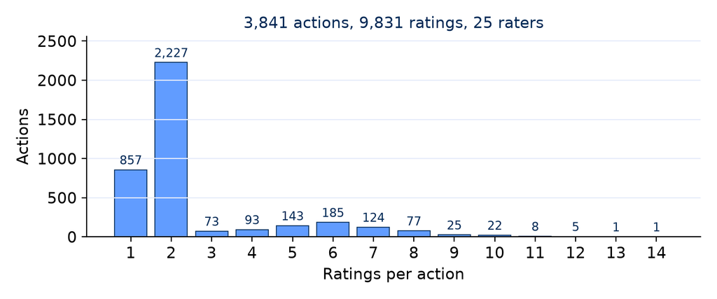

# 3 · The trouble with human raters

## Two actions, same creativity?

[video not shown]

**Dribble A**, Gareth Bale · Wales–Denmark, 8’

Ratings: **6** (R19) and **5** (R02) → raw mean **5.5**

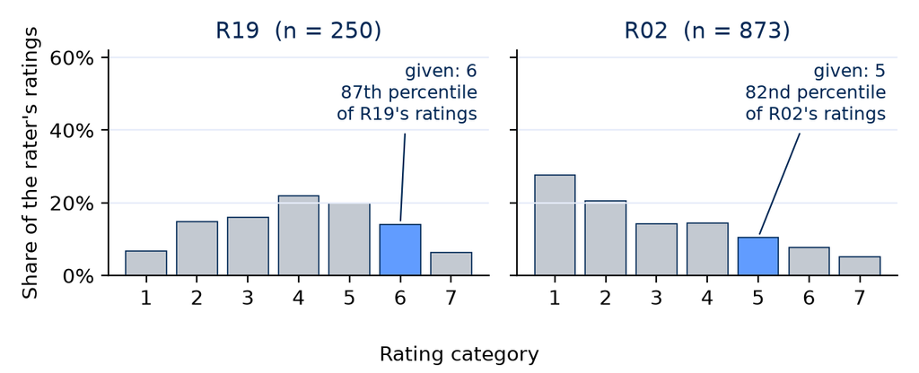

[video not shown]

**Dribble B**, Danilo · Brazil–Serbia, 59’

Ratings: **3** (R01) and **4** (R06) → raw mean **3.5**

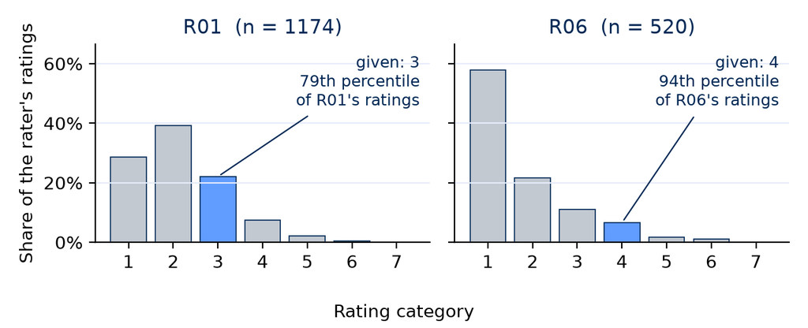

## Who rated them?

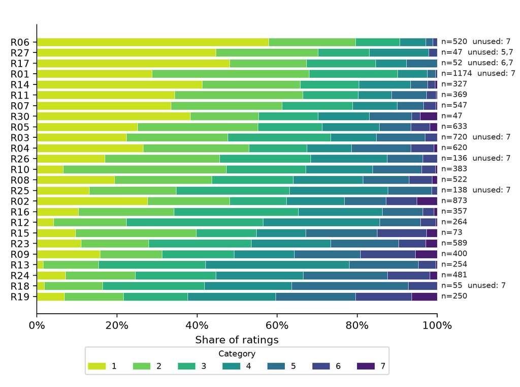

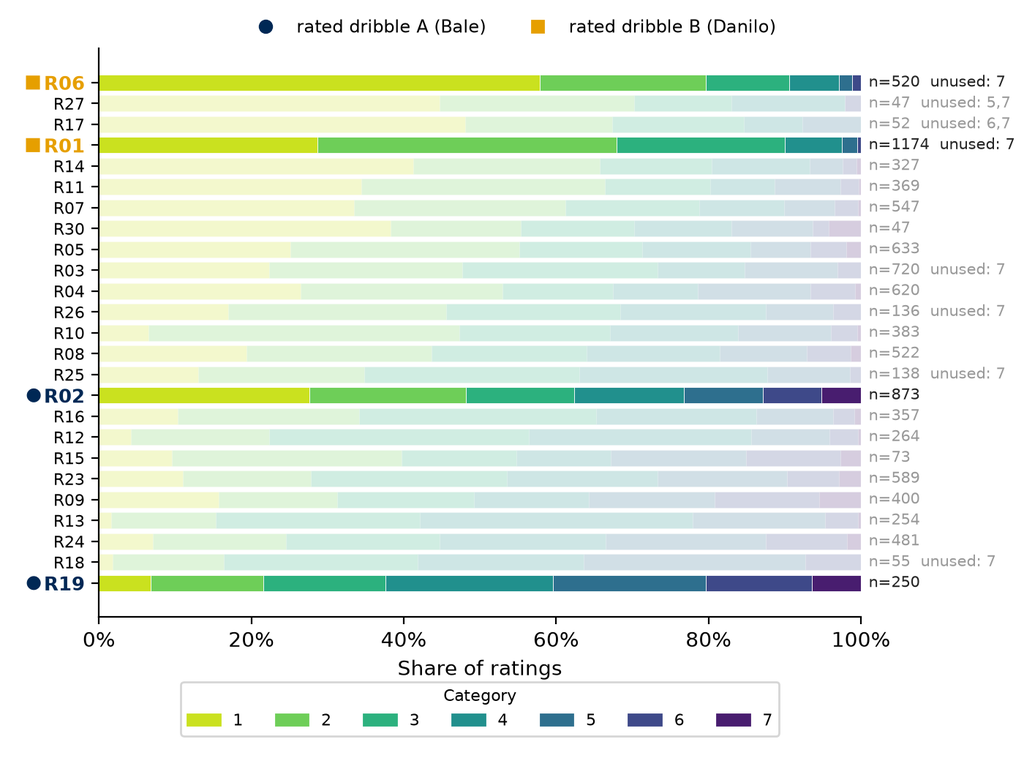

- Raw mean rating per rater: **1.76 (R06) to 4.01 (R19)**.
- Share of the lowest category: **.579 (R06) to .016 (R13)**.
- Eight raters never used at least one category, and none of these eight ever gave a 7.

| Rater | Mean | Given | Percentile |
| --- | --- | --- | --- |
| ● R19 | 4.01 | 6 | 87th |
| ● R02 | 3.03 | 5 | 82nd |
| ■ R01 | 2.16 | 3 | 79th |
| ■ R06 | 1.76 | 4 | 94th |

Percentile: where the given rating sits among the rater’s own ratings. ● dribble A, ■ dribble B.

## The problems, named

**Severity / leniency**  
the same action gets different numbers from different raters.

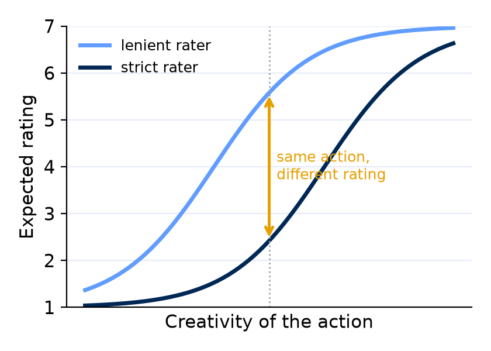

**Category use**  
some raters compress the scale, some never use the top.

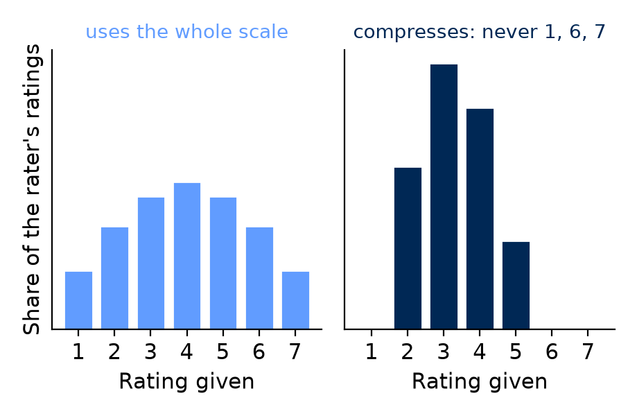

**Discrimination**  
some raters separate actions sharply, others barely.

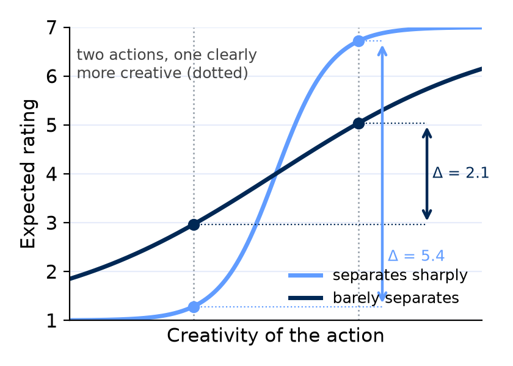

**Agreement of single ratings across all 25 raters: Krippendorff’s α = .402** (Hayes & Krippendorff, 2007). With one or two ratings per action, the raw mean mostly reflects who rated.

## So study 1 became a methods study

**Three research questions**

- **RQ1** How reliable are the scores and how does reliability depend on the **number of ratings per action**?
- **RQ2** How do **raters differ** in severity, scale use and discrimination, and how precisely can we tell?
- **RQ3** Which **model** should be used to estimate rater effects and align the ratings, that is, which assumptions need to be **considered or relaxed**, and how much do scores and rankings depend on that choice?

# 4 · From raw means to judge response theory

## Item response theory

- **A latent variable problem.** θ, the creativity of an action, is unobserved, and it sits on the *predictor* side of the ratings. Ordinary regression needs its predictors observed.
- **The way out**: write down how θ and the rater **generate** a rating, then **invert** the model to recover θ. Item response theory (IRT) is the standard such model for discrete responses.

The probability of a correct response depends on the **person** and on the **item**:

$$P(X_{ij} = 1 \mid \theta_i) = \text{logistic}\big(a_j\,(\theta_i - b_j)\big)$$

- θ<sub>i</sub> **latent trait** of person *i*, say ability.
- b<sub>j</sub> **difficulty** of item *j*: the θ at which the item is solved with probability .5.
- a<sub>j</sub> **discrimination** of item *j*: the slope at b<sub>j</sub>.

**latent creativity** θ  
unobserved

+

**rater tendencies**  
severity, discrimination

↓ probability of each rating 1 to 7 ↓  
**observed rating** X

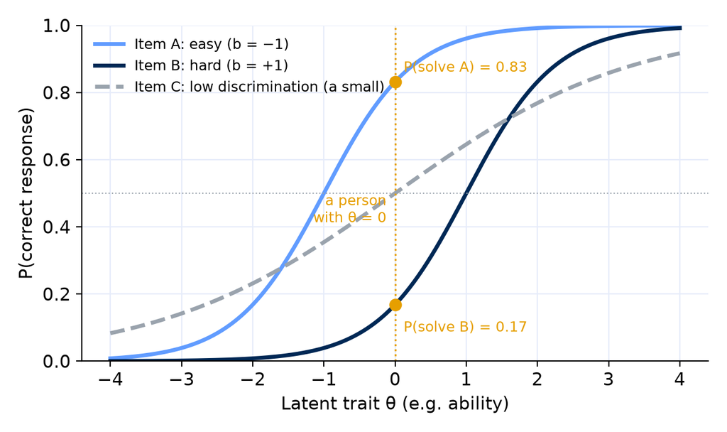

Item characteristic curves of three hypothetical items (Embretson & Reise, 2013; Lord, 1980).

## Judge response theory: the graded response model

- **Items become judges** (Myszkowski, 2021; Myszkowski & Storme, 2019): raters take the role of items, actions the role of persons, and each rater’s behaviour gets its own parameters.
- **Ratings are ordered categories**, so a rater has one slope and **six thresholds** instead of one difficulty.
- **The sparse but connected design** links every rater to the others through shared actions.

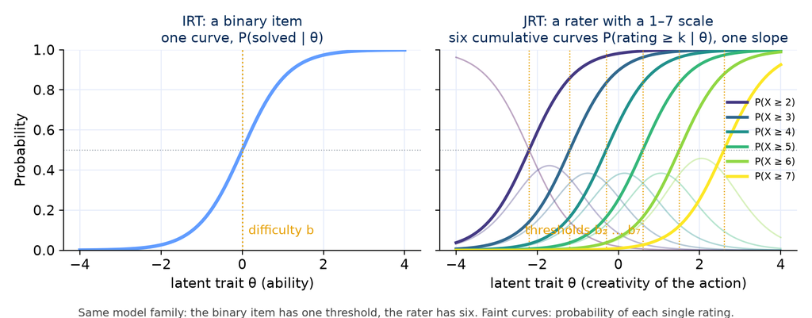

$$P(X_{ij} \ge k \mid \theta_i) = \text{logistic}\big(a_j\,(\theta_i - b_{jk})\big), \qquad k = 2, \dots, 7$$

θ<sub>i</sub> creativity of action i Posterior mean with its own standard error.

b<sub>jk</sub> thresholds of rater j Where a rating ≥ k becomes likely; their location is the **severity**.

a<sub>j</sub> discrimination of rater j The common slope: how sharply the rating responds to θ.

Cumulative form (Samejima, 1969). θ is integrated out; rater parameters by marginal maximum likelihood (EM), actions scored as posterior means, in mirt (Chalmers, 2012).

## The two actions again

|  | ● Dribble A (Bale) | ■ Dribble B (Danilo) |
| --- | --- | --- |
| Raters | R19, R02 | R01, R06 |
| Severity (M1, logits) | **−1.00**, −0.07 | **+0.76, +1.38** |
| Discrimination a | 1.97, 2.60 | 1.79, 3.15 |
| Ratings given | 6, 5 | 3, 4 |
| **Raw mean** | **5.5** | **3.5** |

|  | ● Dribble A | ■ Dribble B |
| --- | --- | --- |
| **GRM score** $\hat\theta$ (SE) | **1.04** (0.46) | **1.34** (0.47) |
| Rating the full panel would give on average | 4.08 | 4.43 |

Last row: model-expected rating at $\hat\theta$, averaged over all 25 raters.

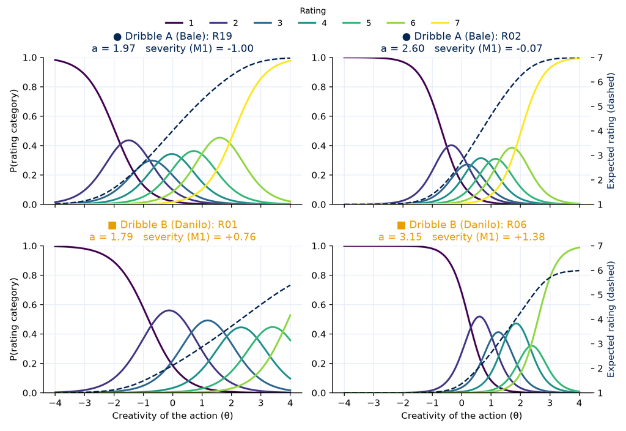

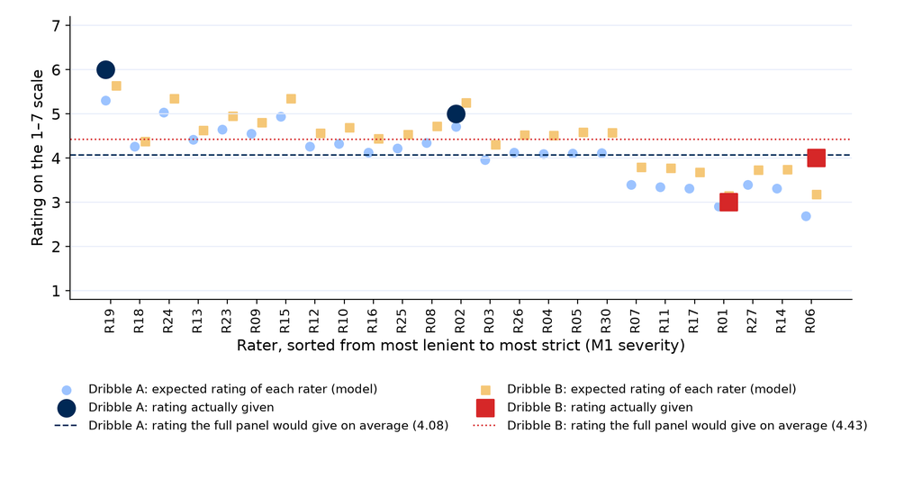

# 5 · Preliminary results

## RQ1 · How many ratings per action?

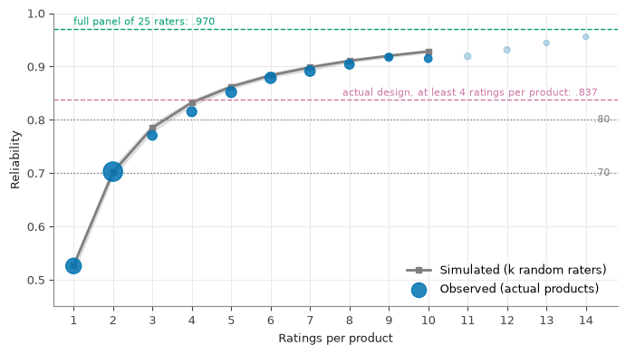

| Ratings | Observed | Simulated |
| --- | --- | --- |
| 1 | .53 | .53 |
| 2 | .70 | .70 |
| 3 | .77 | .79 |
| **4** | **.82** | **.83** |
| 5 | .85 | .86 |
| 10 | .91 | .93 |

- **The scores we actually have**: empirical marginal reliability **.695** [.673, .711], because most actions were rated once or twice.
- In this rater pool, **four ratings** per action are the smallest number that reaches .80.
- Topping the actual design up to four ratings everywhere (+7,098 ratings) lifts .69 to **.84**.

## RQ2 · Raters differ, and some are hard to pin down

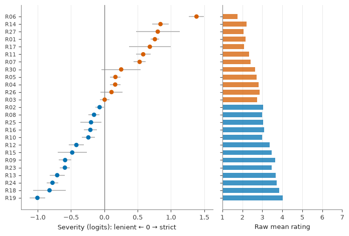

Severity (M1) with 95% intervals; right: raw mean rating.

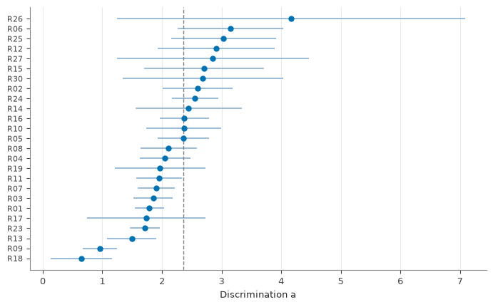

Discrimination $a$ (GRM) with 95% intervals; dashed: median.

- Severity spans **2.39 logits** (−1.00 R19 to +1.38 R06); raw mean and severity do not agree one-to-one (R18).
- Discrimination from **0.65 (R18) to 4.17 (R26)**.
- Information per rating **0.13 (R18) to 3.96 (R26)**: one rating from a sharp rater is worth many from a flat one.
- Raters with about **50 ratings** (R17, R18, R27, R30): intervals too wide to say much.

## RQ2 · All 25 raters

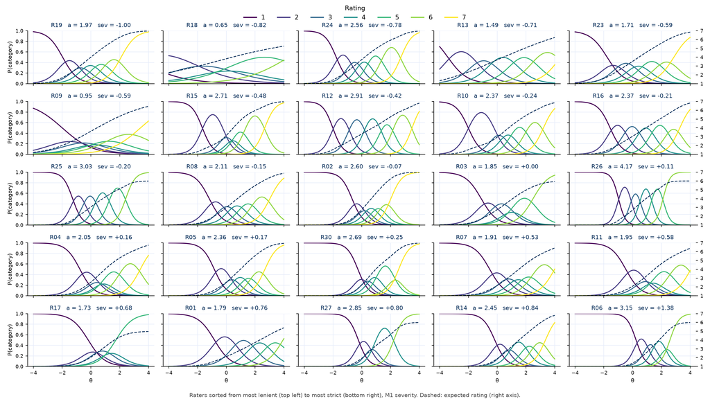

## RQ3 · Does the model matter?

**Model comparison**: each step relaxes a constraint of the model above (lower AIC, BIC, SABIC is better)

| Model | Constraint relaxed, compared with the model above | AIC | BIC | SABIC |
| --- | --- | --- | --- | --- |
| M1 rating-scale MFRM (Eckes, 2015; Linacre, 1989) | the strictest: one severity per rater, **one shared category structure**, equal discrimination | 30,423 | **30,617** | 30,519 |
| M2 partial-credit MFRM | **rater-specific thresholds** | 29,765 | 30,646 | 30,198 |
| M3 generalized partial credit | **rater-specific discrimination** | 29,635 | 30,667 | 30,143 |
| **GRM** graded response model (Samejima, 1969) | same parameters as M3, but **cumulative** P(X ≥ k) instead of adjacent-category odds; not nested | **29,586** | **30,617** | **30,093** |

**Likelihood-ratio tests** (nested pairs)

| Comparison | χ² | df | *p* |
| --- | --- | --- | --- |
| M1 vs M2: rater-specific thresholds | 878.6 | 110 | < .001 |
| M2 vs M3: rater-specific discriminations | 177.4 | 24 | < .001 |

The GRM is not nested and is compared by information criteria only. df of M1 vs M2 would be 120 if every rater had used all 7 categories.

**Final model (GRM) vs raw mean**: how far scores and rankings differ

| Ratings per action | Kendall τ<sub>b</sub> | reversed pairs | $\hat\theta$ range at the same raw mean (mean / max) |
| --- | --- | --- | --- |
| 1 | .77 | 7.6% | 1.24 / 1.42 |
| 2 | .82 | 6.6% | 1.56 / 2.13 |
| 3+ | .86 | 6.5% | 0.51 / 1.31 |

## Contributions

- **Four rater models compared** on a nonverbal product, football actions. Rater-specific thresholds and discrimination fit best.
- **Raters differ too much for raw means.** With one or two ratings per action, the mean mostly reflects who rated.
- **Reliability as a function of the number of ratings.** In this pool, four ratings per action reach .80.
- **Judge response theory adapted to actions in sport.** It yields rater-adjusted scores: better labels for domain research and for training automated models.

## Outlook

**Creative behaviour in competition**, with rater-adjusted scores

- Action-level relations between creativity and **success**: does the creative action lead to the better outcome?
- Creativity in the **context of the game**: score line, pressure, zone, time.
- Creativity as a function of **individual traits** of the player.

**Automated assessment**: the main next step

- Train and compare models on event (and tracking) data to score the creativity of actions: semantic distance, outlier detection, transformers.
- The rater-adjusted scores of study 1 are the training signal and the validation standard for study 2.

## Rate with us: pizza, drinks, and 100 actions

**Tuesday, 24 November 2026 · Room 111 · from 17:30**

An informal team-building evening: everyone is invited to take part in the rating study, with **pizza and drinks** on the side.

- **No participation criteria.** Bring friends, colleagues, anyone who likes football.
- **Rate at least 100 actions** (roughly 20 to 30 minutes, can be split into chunks) and you are eligible for food and drinks.
- The app runs in the browser; a short familiarisation precedes the rating.

**Every rating you give becomes part of the next analysis. The more raters, the fairer the scores.**

## References

Amabile, T. M. (1982). Social psychology of creativity: A consensual assessment technique. *Journal of Personality and Social Psychology*, *43*(5), 997–1013. https://doi.org/10.1037/0022-3514.43.5.997

Barbot, B., & Reiter-Palmon, R. (2019). Creativity assessment: Pitfalls, solutions, and standards. *Psychology of Aesthetics, Creativity, and the Arts*, *13*(2), 131–132. https://doi.org/10.1037/aca0000251

Batey, M. (2012). The measurement of creativity: From definitional consensus to the introduction of a new heuristic framework. *Creativity Research Journal*, *24*(1), 55–65. https://doi.org/10.1080/10400419.2012.649181

Chalmers, R. P. (2012). mirt: A multidimensional item response theory package for the R environment. *Journal of Statistical Software*, *48*(6), 1–29. https://doi.org/10.18637/jss.v048.i06

de Joode, T., van der Kamp, J., & Savelsbergh, G. J. P. (2023). Examining the effect of task constraints on the emergence of creative action in young elite football players by using a method combining expert judgement and frequency count. *Psychology of Sport and Exercise*, *69*, 102502. https://doi.org/10.1016/j.psychsport.2023.102502

de Sa Fardilha, F., & Allen, J. B. (2020). Defining, assessing, and developing creativity in sport: A systematic narrative review. *International Review of Sport and Exercise Psychology*, *13*(1), 104–127. https://doi.org/10.1080/1750984x.2019.1616315

DeCastellarnau, A. (2018). A classification of response scale characteristics that affect data quality: A literature review. *Quality & Quantity*, *52*(4), 1523–1559. https://doi.org/10.1007/s11135-017-0533-4

Eckes, T. (2015). *Introduction to many-facet Rasch measurement: Analyzing and evaluating rater-mediated assessments* (2nd ed.). Peter Lang. https://doi.org/10.3726/978-3-653-04844-5

Embretson, S. E., & Reise, S. P. (2013). *Item response theory*. Psychology Press. https://doi.org/10.4324/9781410605269

Hayes, A. F., & Krippendorff, K. (2007). Answering the call for a standard reliability measure for coding data. *Communication Methods and Measures*, *1*(1), 77–89. https://doi.org/10.1080/19312450709336664

Hennessey, B. A., Amabile, T. M., & Mueller, J. S. (2011). Consensual assessment. In M. A. Runco & S. R. Pritzker (Eds.), *Encyclopedia of creativity* (2nd ed., pp. 253–260). Academic Press. https://doi.org/10.1016/B978-0-12-375038-9.00046-7

Kaufman, J. C., Plucker, J. A., & Baer, J. (2008). *Essentials of creativity assessment*. Wiley.

Kaufman, J. C., Xie, L., & Baer, J. (2024). The consensual assessment technique. In M. A. Runco & S. Acar (Eds.), *Handbook of creativity assessment* (pp. 320–333). Edward Elgar Publishing. https://doi.org/10.4337/9781839102158.00029

Kempe, M., & Memmert, D. (2018). “Good, better, creative”: The influence of creativity on goal scoring in elite soccer. *Journal of Sports Sciences*, *36*(21), 2419–2423. https://doi.org/10.1080/02640414.2018.1459153

Linacre, J. M. (1989). *Many-facet Rasch measurement*. MESA Press.

Lord, F. M. (1980). *Applications of item response theory to practical testing problems*. Lawrence Erlbaum Associates. https://doi.org/10.4324/9780203056615

Lozano, L. M., García-Cueto, E., & Muñiz, J. (2008). Effect of the number of response categories on the reliability and validity of rating scales. *Methodology*, *4*(2), 73–79. https://doi.org/10.1027/1614-2241.4.2.73

Memmert, D. (2010). Testing of tactical performance in youth elite soccer. *Journal of Sports Science & Medicine*, *9 2*, 199–205. https://api.semanticscholar.org/CorpusID:23034858

Memmert, D. (2011). Creativity, expertise, and attention: Exploring their development and their relationships. *Journal of Sports Sciences*, *29*(1), 93–102. https://doi.org/10.1080/02640414.2010.528014

Memmert, D., Hüttermann, S., & Orliczek, J. (2013). Decide like lionel messi! The impact of regulatory focus on divergent thinking in sports. *Journal of Applied Social Psychology*, *43*(10), 2163–2167. https://doi.org/10.1111/jasp.12159

Memmert, D., & Roth, K. (2007). The effects of non-specific and specific concepts on tactical creativity in team ball sports. *Journal of Sports Sciences*, *25*(12), 1423–1432. https://doi.org/10.1080/02640410601129755

Myszkowski, N. (2021). Development of the R library “jrt”: Automated item response theory procedures for judgment data and their application with the consensual assessment technique. *Psychology of Aesthetics, Creativity, and the Arts*, *15*(3), 426–438. https://doi.org/10.1037/aca0000287

Myszkowski, N., & Storme, M. (2019). Judge response theory? A call to upgrade our psychometrical account of creativity judgments. *Psychology of Aesthetics, Creativity, and the Arts*, *13*(2), 167–175. https://doi.org/10.1037/aca0000225

OECD. (2024). *PISA 2022 results (Volume III): Creative minds, creative schools*. OECD Publishing. https://doi.org/10.1787/765ee8c2-en

Organisciak, P., Acar, S., Dumas, D., & Berthiaume, K. (2023). Beyond semantic distance: Automated scoring of divergent thinking greatly improves with large language models. *Thinking Skills and Creativity*, *49*, 101356. https://doi.org/10.1016/j.tsc.2023.101356

Preston, C. C., & Colman, A. M. (2000). Optimal number of response categories in rating scales: Reliability, validity, discriminating power, and respondent preferences. *Acta Psychologica*, *104*(1), 1–15. https://doi.org/10.1016/S0001-6918(99)00050-5

Primi, R., Silvia, P. J., Jauk, E., & Benedek, M. (2019). Applying many-facet Rasch modeling in the assessment of creativity. *Psychology of Aesthetics, Creativity, and the Arts*, *13*(2), 176–186. https://doi.org/10.1037/aca0000230

Rhodes, M. (1961). An analysis of creativity. *The Phi Delta Kappan*, *42*(7), 305–310.

Roca, A., Ford, P. R., & Memmert, D. (2018). Creative decision making and visual search behavior in skilled soccer players. *PLOS ONE*, *13*(7), e0199381. https://doi.org/10.1371/journal.pone.0199381

Runco, M. A., & Jaeger, G. J. (2012). The standard definition of creativity. *Creativity Research Journal*, *24*(1), 92–96. https://doi.org/10.1080/10400419.2012.650092

Samejima, F. (1969). Estimation of latent ability using a response pattern of graded scores. *Psychometrika*, *34*(S1), 1–97. https://doi.org/10.1007/BF03372160

Santos, S. D. L., Memmert, D., Sampaio, J., & Leite, N. (2016). The spawns of creative behavior in team sports: A creativity developmental framework. *Frontiers in Psychology*, *7*, 1282. https://doi.org/10.3389/fpsyg.2016.01282

Snyder, H. T., Hammond, J. A., Grohman, M. G., & Katz-Buonincontro, J. (2019). Creativity measurement in undergraduate students from 1984–2013: A systematic review. *Psychology of Aesthetics, Creativity, and the Arts*, *13*(2), 133–143. https://doi.org/10.1037/aca0000228

Stein, M. I. (1953). Creativity and culture. *The Journal of Psychology*, *36*(2), 311–322. https://doi.org/10.1080/00223980.1953.9712897

World Economic Forum. (2025). *The future of jobs report 2025*. World Economic Forum. https://www.weforum.org/publications/the-future-of-jobs-report-2025/

# Backlog

## Backlog · Creativity research in sport

**Mostly the creative *process*: divergent thinking in game situations**

- Video or game-test situations, frozen at a decision point; players name or demonstrate all possible solutions.
- Scored for fluency, flexibility and originality, often “adequacy” as well. Handball, football, children to elite youth (Memmert, 2010, 2011; Memmert et al., 2013; Memmert & Roth, 2007).

**Rarely the creative *product* in competition**

- Kempe & Memmert (2018): last eight actions before goals at World Cups 2010/2014 and Euro 2016, rated 1–10 by three UEFA-licensed coaches, trained on the scale. Creativity rose towards the goal and predicted success.
- Later: academy games (de Joode et al., 2023), video scenes (Roca et al., 2018): three or four raters, an intraclass correlation, and that is it.

**Open**: how creative behaviour in competition unfolds with the game context and with player traits. No study asks how many raters such ratings need, or how raters differ.

## Backlog · The data

| Quantity | Value |
| --- | --- |
| Ratings | **9,831** |
| Actions (products) | **3,841** |
| Raters | **25** (47 to 1,174 ratings each) |
| Ratings per action | mean 2.56, median 2, range 1–14 |
| Design | incomplete but **connected**; 23 of 300 rater pairs share no action |

Excluded: five raters with fewer than 15 ratings (32 ratings). Ratings marked “not recognised” removed.

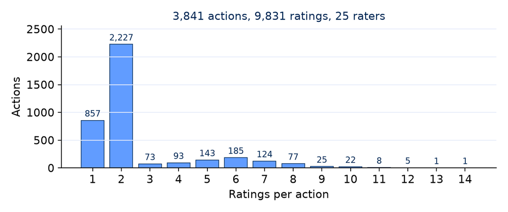

## Backlog · A ladder of constrained models

| Model | Name | Relaxes, compared with the model above |
| --- | --- | --- |
| **M1** | Rating-scale many-facet Rasch model (Eckes, 2015; Linacre, 1989) | the strictest: one severity per rater, **one shared category structure**, equal discrimination |
| **M2** | Partial-credit MFRM | **rater-specific thresholds**: each rater has their own category structure |
| **M3** | Generalized partial credit model | **rater-specific discrimination** |
| **GRM** | Graded response model (Samejima, 1969) | same parameters as M3, but models the **cumulative** probability P(X ≥ k) instead of adjacent-category odds; not nested in M1–M3 |

The constraints become **testable**: likelihood-ratio tests for the nested pairs (M1 vs M2, M2 vs M3) and AIC, BIC and SABIC for all four models (Primi et al., 2019).

## Backlog · Why a 7-point unipolar scale

- Large comparative experiments: reliability, validity and discrimination improve with the number of categories up to about **7–10**, with diminishing returns beyond 7 and more response error when scales get too long; 7 was often optimal across outcomes (Preston & Colman, 2000).
- Simulation plus empirical review: the optimum lies between **4 and 7**; little psychometric gain above 7, and below 4 both reliability and validity drop (Lozano et al., 2008).
- Reviews of response-scale design agree: too few categories under-discriminate, too many add cognitive load and noise (DeCastellarnau, 2018).
- **Unipolar**, because creativity is an amount of a property, not a valence around a neutral point. Labels in the app: 1 “not creative”, 7 “very creative”.
- Three dimensions were rated, creativity, technical correctness and aesthetic appeal, so that construct validity can be examined later, as Amabile (1982) recommends for a new domain.

## Backlog · The definition the raters read

**Creativity in soccer**

Creativity is defined as the product of originality and functionality. A creative solution must be **original** (novel, rare, unusual) as well as **functional** (it must provide a solution to the given problem).

Creativity in soccer describes the ability to choose solutions or execute actions in a given game situation that deviate from the norm, appear surprising, and are potentially advantageous for one’s own team. It arises from the conscious perception of the situation and the recognition of possibilities that others do not see, or see only later.

A creative action must be functional: it must (potentially) bring one’s own team closer to the game objective (scoring, preventing goals). What matters is the **intention or idea** and the **expected probability of success**, not the actual outcome.

Text of the app (German and English), shown before the familiarisation clips and available at any time during rating. Definition after Runco & Jaeger (2012); no further criteria, following the CAT.

## Backlog · How reliable are the ratings right now?

**The agreement of single ratings is poor**

- Krippendorff’s ordinal α = **.402** [.375, .427] over 25 raters and 3,841 actions. Two raters watching the same action often give different numbers.
- The index is built for incomplete designs with missing cells (Hayes & Krippendorff, 2007), so it fits our data. But it describes **single ratings**, not a score.

**Cronbach’s α looks fine, and misleads**

- α = **.959**, the figure a conventional report would show.
- It is computed from pairwise covariances (18 raters, 1,948 actions) and describes a **hypothetical mean over the whole panel**. No action was rated by everyone; the only fully crossed block (3 raters × 270 actions) gives α = .79.
- It says nothing about the score of an action rated by one or two people.

**And the design is sparse and unbalanced.** 1 to 14 ratings per action, from different raters each time. The raw mean of an action therefore confounds the action with its panel, and with one or two ratings there is no crowd whose wisdom could average the rater out.

Averaging treats raters as interchangeable. They are not. We need a model in which the **rater is part of the measurement**.

## Backlog · How such models are fitted: marginal maximum likelihood

**The problem**

- The likelihood of a response pattern is a product over items, and it contains the unknown θ of every person (here: every action).
- Treating every θ as a free parameter fails: their number grows with the sample, and the estimates do not converge.

**The solution**

- **Marginal likelihood**: integrate θ out under its population distribution, N(0, 1):
  $$L_i = \int \prod_j P(X_{ij} \mid \theta)\, \varphi(\theta)\, d\theta$$
- Maximise over the item (rater) parameters with an **EM algorithm**: E-step, the posterior of θ for each person on a quadrature grid; M-step, update the item parameters.
- Afterwards, each θ is scored as a **posterior mean** (EAP) with a posterior standard deviation. Implemented in mirt (Chalmers, 2012).

## Backlog · What the parameters do

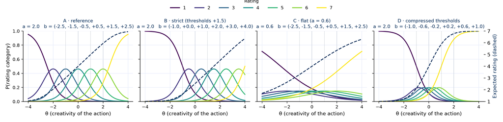

**Expected rating of an action with creativity θ**

| Rater | θ = −1 | θ = 0 | θ = +1 | θ = +2 |
| --- | --- | --- | --- | --- |
| A · reference | 3.01 | 4.00 | 4.99 | 5.94 |
| B · strict (thresholds +1.5) | 1.64 | 2.52 | 3.50 | 4.50 |
| C · flat (a = 0.6) | 3.29 | 4.00 | 4.71 | 5.36 |
| D · compressed thresholds | 2.12 | 4.00 | 5.88 | 6.78 |

- **Shift the thresholds** (B): every action gets about 1.5 points less. *Severity.*
- **Lower a** (C): the actions at θ = −1 and +2 are 2.9 points apart for A, 2.1 for C. *Discrimination.*
- **Compress the thresholds** (D): the whole scale is used over a narrow θ range; beyond it the rating saturates at 1 or 7. *Category use.*

## Backlog · RQ2 · Where the information comes from

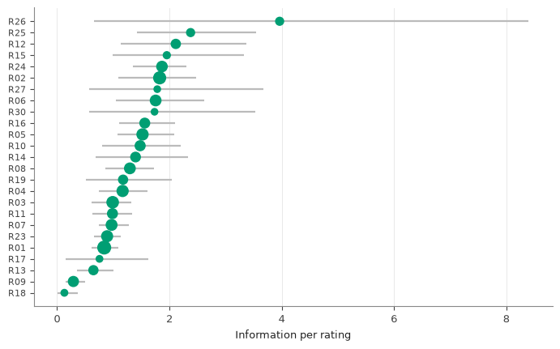

Average information per rating (integrated over θ ~ N(0, 1)) for each rater, 95% intervals from 200 parameter draws; point size ∝ √(number of ratings).

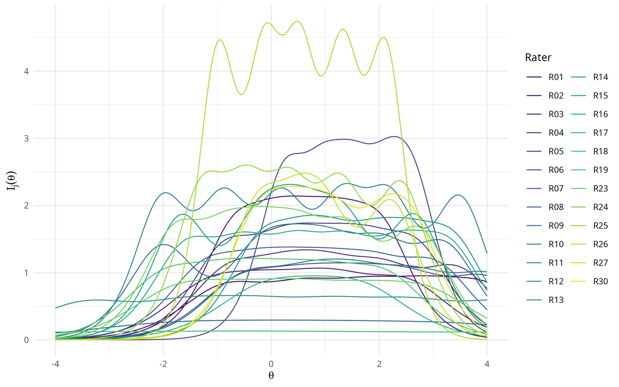

Rater information functions $I_j(\theta)$ of the graded response model.

- Information per rating ranges from **0.13 (R18) to 3.96 (R26)**: one rating from a sharp rater is worth many from a flat one.
- Sharp raters inform mostly where their thresholds sit, in the middle of the θ range; flat raters inform almost nowhere.

## Backlog · What follows for rating studies of actions in sport

1. **Report the reliability of the scores actually used**, and the agreement of single ratings, not only alpha or full-panel values (.69 vs .96 and .97 here).
2. **Plan several ratings per action.** One or two gave .53 and .70; four reached .80 in this pool.
3. **Let all raters rate a common calibration set**, so that raters are linked and the parameters of raters with few ratings become estimable. (Not the same as training, which conflicts with the CAT’s “no criteria” rule.)
4. **Give each rater enough ratings.** About 50 still left the parameters imprecise.
5. **Consider rater-adjusted scoring** and report how far it departs from raw means. The data do not show that model scores are more *valid*, only that raw means carry rater effects.
6. **Treat these figures as specific** to this product class, rater pool and scale.